# CMPINF 2100 - Intro to Data Centric Computing FINAL PROJECT

## Travis Rogan

### Project Summary

The project that I selected is the Pitt Athletics data set. The data set contains real, anonymous information from University of Pittsburgh football season ticket holders (STH). Information about the season ticket holders included:

- Age
- Gender
- Distance and direction from Acrisure Stadium
- Drive times to Acrisure Stadium
- Month and Day of the Week tickets were purchased
- Ticket price type
- Ticket price level
- Number of tickets
- Price per ticket
- Whether or not the STH renewed their tickets for the following year

The problem associated with this data set was to formulate a data model that would predict whether or not a future STH would renew their season tickets based on the information provided above.

This problem is a **classification** problem. The objective was to correctly classify individuals into one of two categories: Non-Event/0 (Did/will not renew season tickets) or Event/1 (Did/will renew season tickets)

```python
import numpy as np
import pandas as pd
import matplotlib.pyplot as plt
import seaborn as sns
```

```python
import statsmodels.formula.api as smf
```

```python
from sklearn.metrics import confusion_matrix
from sklearn.metrics import roc_curve
from sklearn.metrics import roc_auc_score
```

```python
pitt_df = pd.read_csv('pitt_athletics_cmpinf2100_project.csv')
```

# Exploratory Data Analysis

```python
pitt_df.shape
#B.a.i.1
```

```
(3360, 15)
```

```python
pitt_df.info()
#B.a.i.2,3
```

```
<class 'pandas.core.frame.DataFrame'>
RangeIndex: 3360 entries, 0 to 3359
Data columns (total 15 columns):
 #   Column              Non-Null Count  Dtype
---  ------              --------------  -----
 0   accountid           3360 non-null   int64
 1   age                 1567 non-null   float64
 2   gender              582 non-null    object
 3   distancemiles       3360 non-null   float64
 4   direction           3360 non-null   object
 5   peak_drivetime      2958 non-null   float64
 6   offpeak_drivetime   2996 non-null   float64
 7   season              3360 non-null   int64
 8   purchase_month      3360 non-null   object
 9   purchase_dow        3360 non-null   object
 10  price_type          3360 non-null   object
 11  price_level         3360 non-null   object
 12  ticket_count        3360 non-null   int64
 13  price_per_ticket    3360 non-null   float64
 14  return_next_season  3360 non-null   object
dtypes: float64(5), int64(3), object(7)
memory usage: 393.9+ KB
```

```python
pitt_df.isna().sum()
#B.a.i.4
```

```
accountid                0
age                   1793
gender                2778
distancemiles            0
direction                0
peak_drivetime         402
offpeak_drivetime      364
season                   0
purchase_month           0
purchase_dow             0
price_type               0
price_level              0
ticket_count             0
price_per_ticket         0
return_next_season       0
dtype: int64
```

```python
pitt_df.nunique()
#B.a.i.5
```

```
accountid             3360
age                     70
gender                   4
distancemiles         3300
direction                8
peak_drivetime        2311
offpeak_drivetime     2333
season                   1
purchase_month           3
purchase_dow             6
price_type               4
price_level              8
ticket_count            20
price_per_ticket       113
return_next_season       2
dtype: int64
```

### Continous Variables

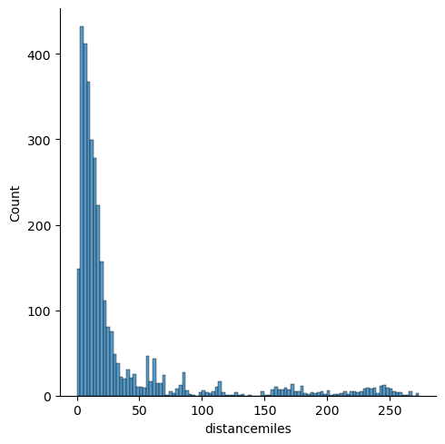

```python
sns.displot(data = pitt_df, x = 'distancemiles', kind = 'hist')

plt.show()
```

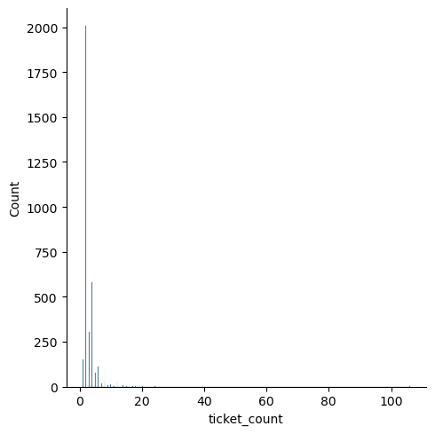

```python
sns.displot(data = pitt_df, x = 'ticket_count', kind = 'hist')

plt.show()
```

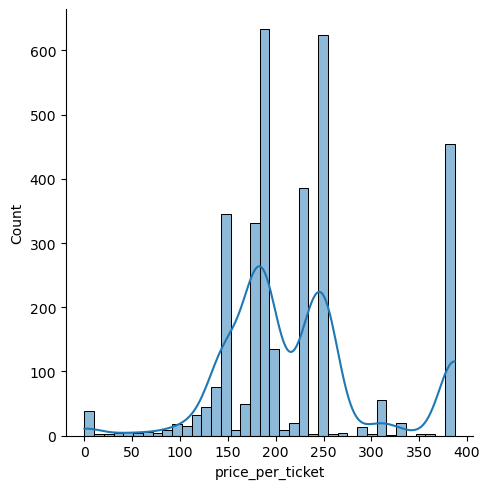

```python
sns.displot(data = pitt_df, x = 'price_per_ticket', kind = 'hist', kde = True)

plt.show()
```

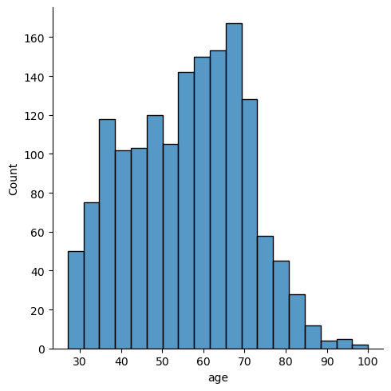

```python
sns.displot(data = pitt_df, x = 'age', kind = 'hist')

plt.show()
```

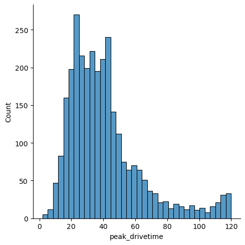

```python
sns.displot(data = pitt_df, x = 'peak_drivetime', kind = 'hist')

plt.show()
```

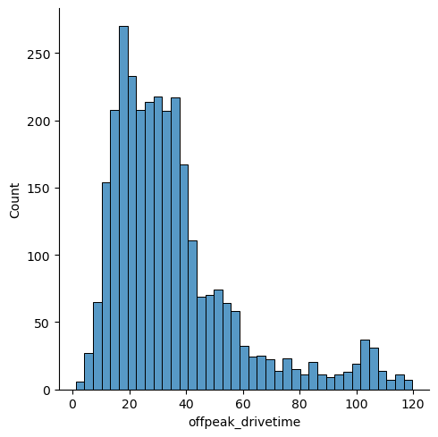

```python
sns.displot(data = pitt_df, x = 'offpeak_drivetime', kind = 'hist')

plt.show()
```

### Categorical Variables

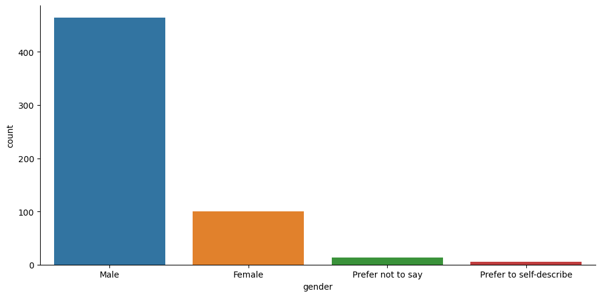

```python
sns.catplot(data = pitt_df, x = 'gender', kind = 'count', aspect = 2)

plt.show()
```

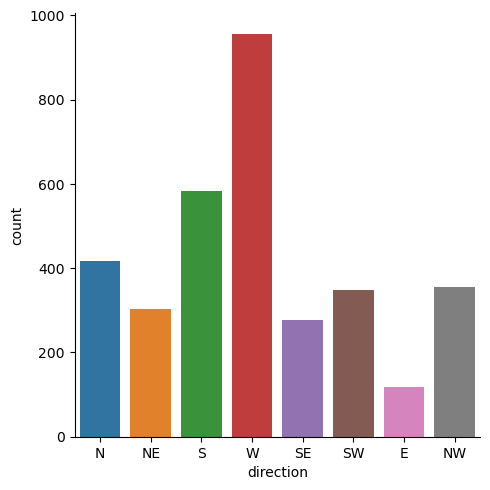

```python
sns.catplot(data = pitt_df, x = 'direction', kind = 'count')

plt.show()
```

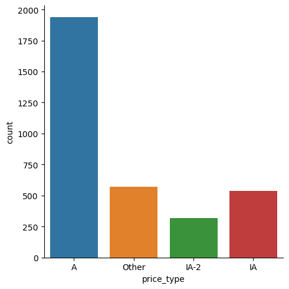

```python
sns.catplot(data = pitt_df, x = 'price_type', kind = 'count')

plt.show()
```

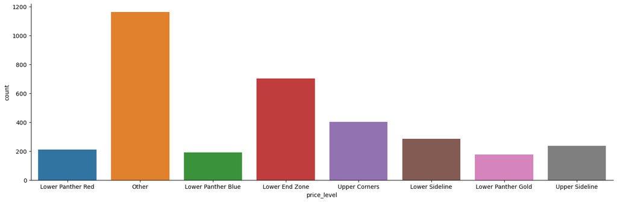

```python
sns.catplot(data = pitt_df, x = 'price_level', kind = 'count', aspect=3 )

plt.show()
```

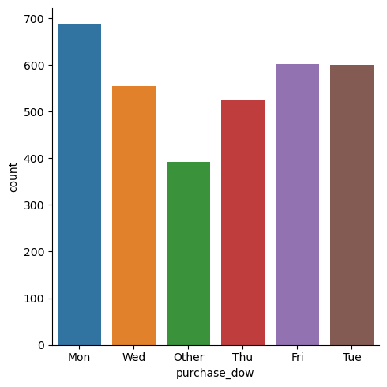

```python
sns.catplot(data = pitt_df, x = 'purchase_dow', kind = 'count')

plt.show()
```

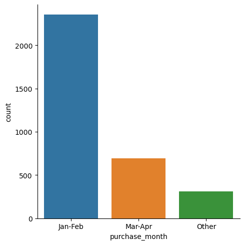

```python
sns.catplot(data = pitt_df, x = 'purchase_month', kind = 'count')

plt.show()
```

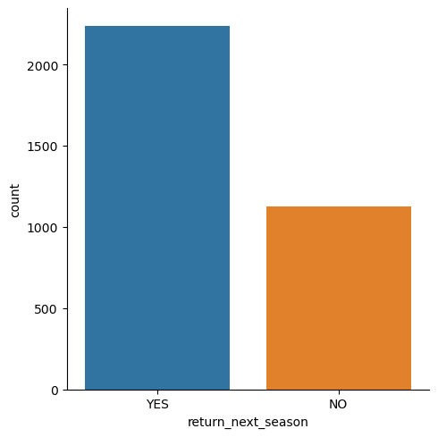

```python
sns.catplot(data = pitt_df, x = 'return_next_season', kind = 'count')

plt.show()
```

### Relationships of Continuous Variables

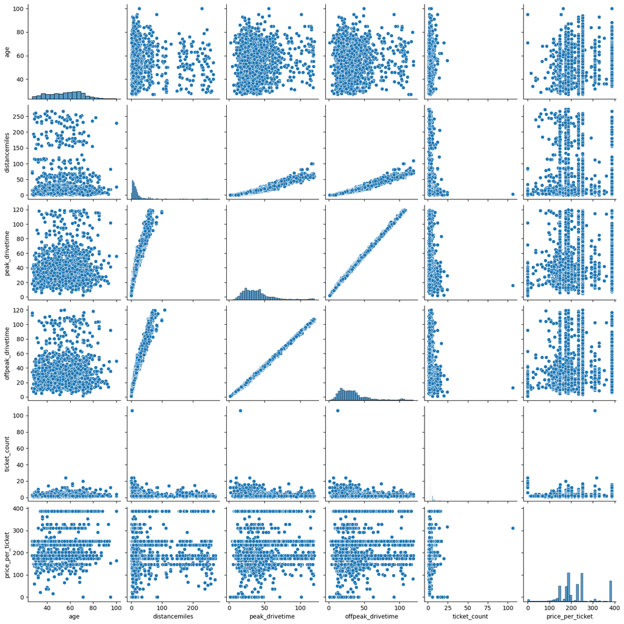

```python
sns.pairplot(data= pitt_df, vars=['age', 'distancemiles', 'peak_drivetime', 'offpeak_drivetime', 'ticket_count', 'price_per_ticket'])

plt.show()
```

### Outcome Values

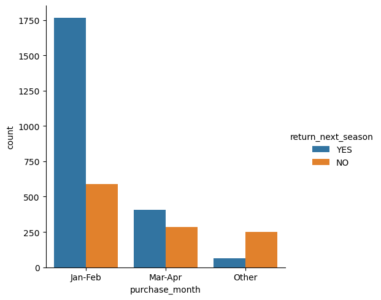

```python
sns.catplot(data = pitt_df, x = 'purchase_month', kind = 'count', hue = 'return_next_season')

plt.show()
```

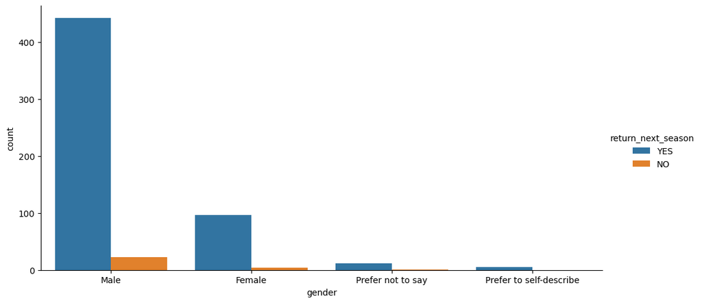

```python
sns.catplot(data = pitt_df, x = 'gender', kind = 'count', hue = 'return_next_season', aspect = 2)
plt.show()
```

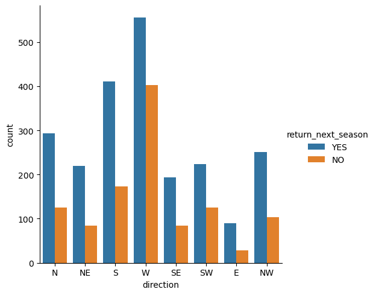

```python
sns.catplot(data = pitt_df, x = 'direction', kind = 'count', hue = 'return_next_season')

plt.show()
```

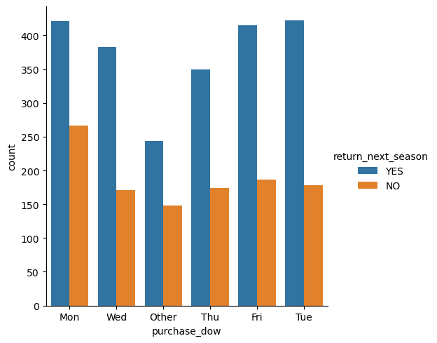

```python
sns.catplot(data = pitt_df, x = 'purchase_dow', kind = 'count', hue = 'return_next_season')

plt.show()
```

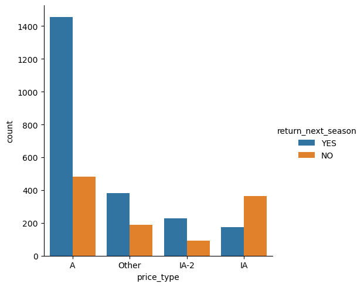

```python
sns.catplot(data = pitt_df, x = 'price_type', kind = 'count', hue = 'return_next_season')

plt.show()
```

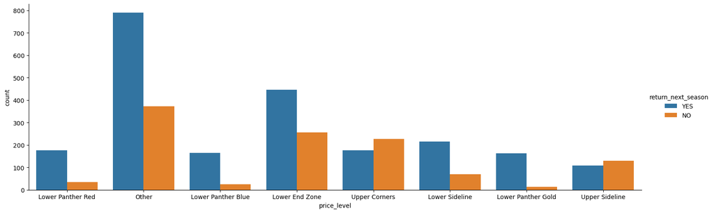

```python
sns.catplot(data = pitt_df, x = 'price_level', kind = 'count', hue = 'return_next_season', aspect=3)

plt.show()
```

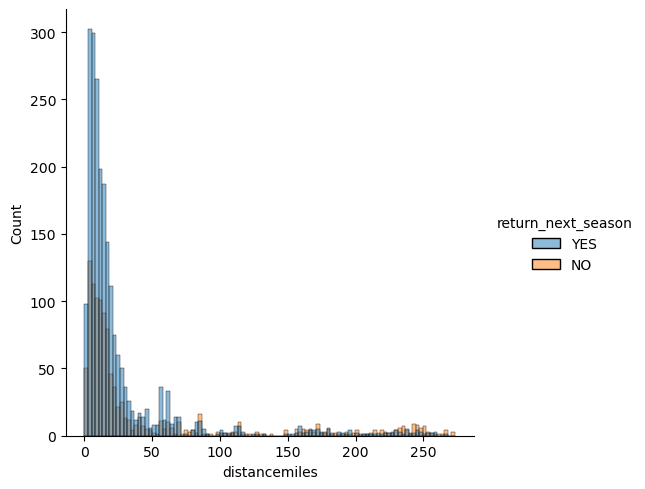

```python
sns.displot(data = pitt_df, x = 'distancemiles', hue= 'return_next_season',kind = 'hist')

plt.show()
```

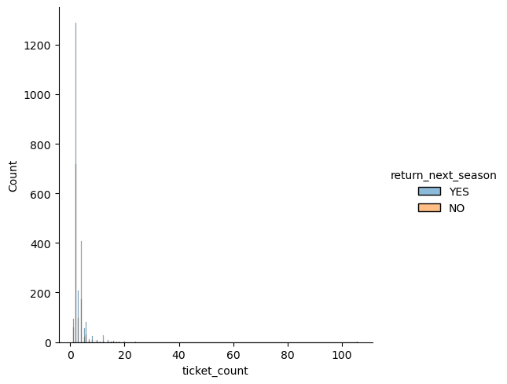

```python
sns.displot(data = pitt_df, x = 'ticket_count', hue = 'return_next_season',kind = 'hist')

plt.show()
```

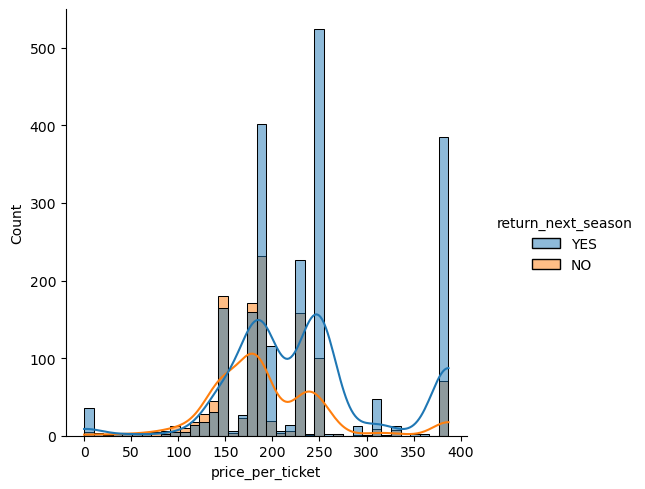

```python
sns.displot(data = pitt_df, x = 'price_per_ticket', kind = 'hist', hue = 'return_next_season', kde = True)

plt.show()
```

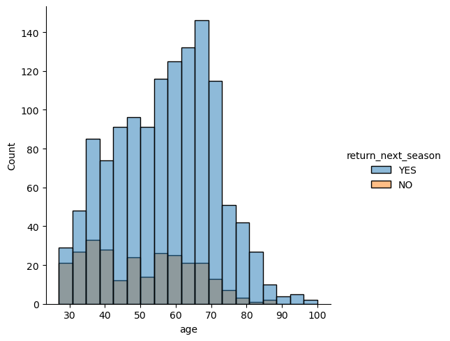

```python
sns.displot(data = pitt_df, x = 'age', hue = 'return_next_season',kind = 'hist')

plt.show()
```

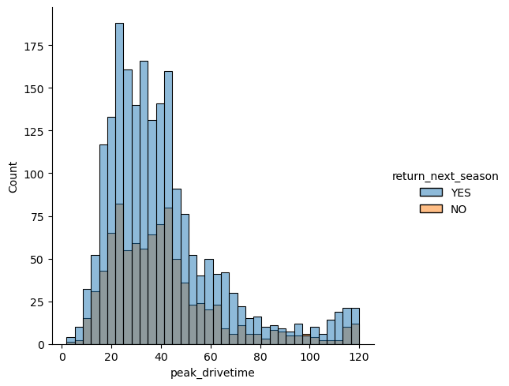

```python
sns.displot(data = pitt_df, x = 'peak_drivetime', hue = 'return_next_season',kind = 'hist')

plt.show()
```

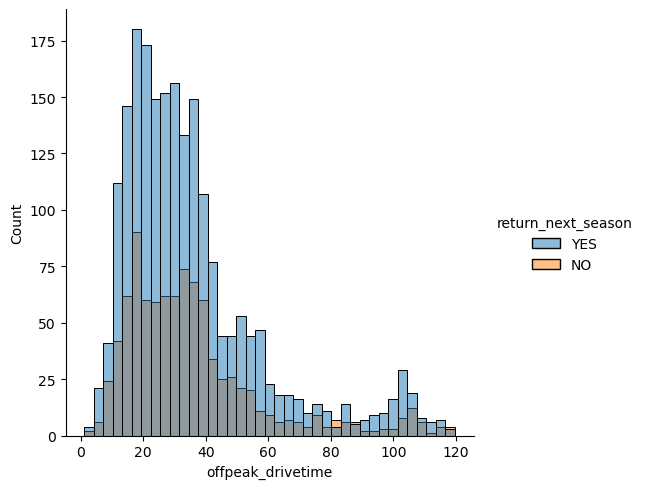

```python
sns.displot(data = pitt_df, x = 'offpeak_drivetime', hue = 'return_next_season',kind = 'hist')

plt.show()
```